# Who they are becoming

Week 4 · Chapter 3 · Personality, Identity and Moral Development

Study · Week 4

Read Chapter 3 of the textbook (Eggen & Kauchak, 2025) before you read this brief. Last week you studied how thinking changes. This week you study **who is doing the thinking**, and how much of that person you can measure, name or influence.

About 25 minutes: reading, one place you stop and write, and 8 quick checks.

Pair this with **the Walkthrough**, a 13-minute video in which I apply one framework to Maya’s letter and find that it does not settle the question.

## The claim you already believe

**Many people believe that personality explains behavior.** A student is disorganized, so she forgets the homework. A student is shy, so he does not speak in group work. In this view, the trait is the cause and the behavior is the evidence.

The explanation is comfortable, and it is almost circular, because the same behavior serves as the evidence for the trait and as its effect. This week you will examine how much that explanation can support.

Begin with the case. Maya’s mother says she has been *impossible* since the sketchbooks were put away. Three days later, the counselor writes *composed, articulate, not defiant*. Two adults who both know Maya describe the same adolescent in the same two weeks.

At most one of them is describing a trait.

## Have you ever taken a Buzzfeed personality test?

Many of us have taken one, and finding out which Disney character you are can be fun. It is still worth asking what those tests are doing. Three questions apply to every instrument you will ever receive, including the one attached to this week:

What is it for? What decision would this result change? If it changes no decision, the result is entertainment. That is fine, as long as nobody puts it in a student’s file.

Where did the questions come from? Who wrote them, who tested them, and with whom? Validated instruments have published evidence across populations. Quizzes only have a writer.

What is the value of knowing? How does the result help the person who took the test? This question matters most when you give a student a score.

Remember these questions. Your students meet personality tests constantly on social media, and they increasingly meet tools that profile them from a paragraph of their writing, although nobody has validated those tools on anyone.

True or false?

If a personality quiz gives you a result that feels accurate, it is a valid measure.

Not quite Almost any vague result feels accurate. Validity needs evidence across populations, so ask the three questions: what is it for, where did the questions come from, and what is the value of knowing?

Right Vague results feel accurate to almost everyone. Validity needs published evidence across populations.

## Temperament and personality

Temperament: the biologically based foundation. Temperament appears early, is largely genetic, and is hard to modify. It influences emotional reactivity, self-regulation and adaptability before other factors do.

Personality: what develops on that foundation. Personality includes patterns of thinking, feeling and behaving that experience, context and relationships influence over time.

Three temperament patterns appear early and persist (Thomas & Chess, 1977):

Easy: adaptable, regular, quickly settled. These children are cheerful and flexible, have predictable routines, and adjust easily to change.

Difficult: intense, irregular, slow to adapt. These children have high emotional reactivity and are more prone to frustration. The label is unkind, but the pattern is real.

Slow-to-warm-up: cautious first, then comfortable. These children wait and watch before they join. Their caution looks like reluctance, and it is a different thing.

The distinction has consequences for teaching. **Temperament tells you what a student arrives with, and personality is where teaching has more influence.** When a teacher encourages a slow-to-warm-up student to join right away, the encouragement adds pressure. The student needs the two minutes they were always going to take.

True or false?

A slow-to-warm-up student needs extra encouragement to join in right away.

Not quite Encouragement adds pressure. A slow-to-warm-up student needs the two minutes they were always going to take.

Right Give them time. The pattern looks like reluctance and is something else.

## The Big Five and its limits

Five broad dimensions, known as **OCEAN**, have a genuine research base across populations and cultures (McCrae & Costa, 1997), which a Buzzfeed quiz does not have.

Openness: imagination, curiosity and interest in the unfamiliar. High: explores widely, enjoys intellectual challenge. Low: prefers the known, values routine.

Conscientiousness: organization, dependability and self-discipline. High: plans, follows through, manages time. Low: spontaneous, less organized, more prone to putting things off.

Extraversion: sociability, assertiveness and enthusiasm. High: seeks interaction, speaks in groups. Low: reflective, prefers fewer people, quieter in the room.

Agreeableness: warmth, cooperation and trust. High: accommodating, avoids conflict. Low: challenges, argues, less concerned with harmony.

Neuroticism: emotional reactivity and negative affect. High: worries, ruminates, feels setbacks sharply. Low: even-keeled, recovers quickly.

Check yourself

A student loves debating, challenges classmates’ ideas, cares little about keeping the peace, and is happiest in a big group. Which pair fits best?

Half right Big groups point to high extraversion. Challenging others and not caring about harmony points to **low** agreeableness.

Yes The student seeks interaction and speaks up (high extraversion), and argues with less concern for harmony (low agreeableness).

No sign of either Nothing here is about worry or about preferring the familiar.

Opposite on extraversion Happiest in a big group is high extraversion.

**Conscientiousness is the strongest personality predictor of academic performance** (Poropat, 2009). That finding is robust, and it is the one everybody remembers.

People often forget a second finding:

Cognitive ability and personality **together** account for roughly **28% of the variance** in academic performance (Mammadov, 2022). Ability accounts for most of that share, and conscientiousness accounts for most of the rest.

About **seventy percent** of the variance remains, which includes circumstance, teaching, opportunity, relationship and chance.

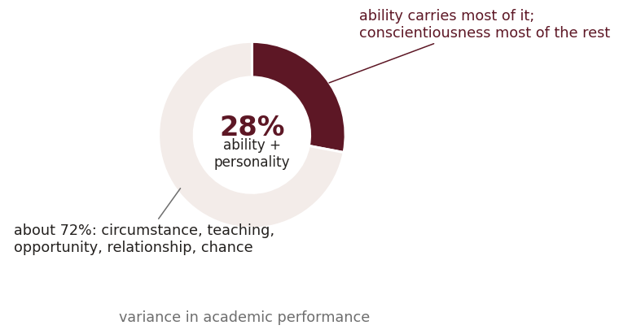

What 28% leaves. Ability and personality together explain a real share of academic performance (Mammadov, 2022), and most of the variance comes from other sources.

**A trait describes a tendency, and it cannot forecast one event.** Twenty-eight percent is a real effect and a terrible basis for a prediction about one child. When a teacher uses a trait score to explain what a particular student did on a particular Tuesday, the score has to carry about three times what it can hold.

The way we use the score also matters. *“He is low in conscientiousness”* ends an inquiry, whereas *“He has no system for tracking what is due, and nobody has ever built him one”* starts one.

**Can personality change?** It changes somewhat. Life events produce small and inconsistent effects (Bleidorn et al., 2018), which are larger in the work domain, such as graduation or a first job, than in the love domain. Gains push one way, and losses push the other. This evidence does not support a claim that you will change a student’s personality, but plenty of evidence supports the claim that you can change what it costs them.

Commit first

You have a student who scores low on conscientiousness. He misses deadlines, loses handouts, and starts essays the night before.

**Name one thing you would do differently on Monday because of the score.** Then say what you would have done anyway without it, and explain what the score added. Two or three sentences.

**If the two answers are the same, the score added nothing.** This is an honest test of any measurement, and most measurements fail it most of the time.

A trait score is not very useful for choosing the intervention, because you would have built the tracking system regardless. It is useful for deciding **how long you expect to keep the system**, and for **not reading the failure as refusal**.

When a student high in conscientiousness misses three deadlines, something has changed, and you need to ask what. When a student low in conscientiousness misses three deadlines, the student is doing what the trait predicts, and you need to ask what structure is missing. The behavior is the same, and the score helps you choose between the two questions.

This use is genuine, and it is much smaller than the use people usually make of a trait score.

## Two strategies of emotion regulation

Chapter 3 describes emotion regulation. A useful distinction is *when* each strategy happens:

Reappraisal: change how you interpret the situation. Reappraisal happens early, before the emotion is fully built. For example: “This is hard because it is new, not because I cannot do it.”

Suppression: manage the outward expression. Suppression happens late, when the feeling is fully formed. It changes only what other people see.

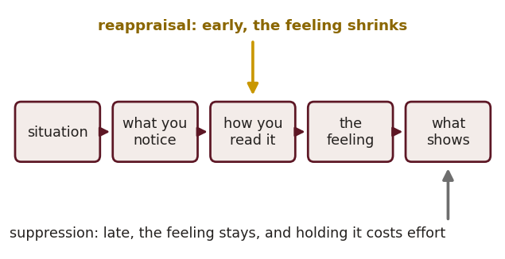

When each strategy acts (Gross & John, 2003). Reappraisal changes the input, whereas suppression changes only what shows.

Both strategies work in the short term, but their costs differ. Reappraisal changes the input, so the feeling itself is smaller. Suppression leaves the input intact and adds the effort of holding back the expression, and that effort uses the same working memory the lesson needs.

**“Talking about it” is different from both strategies.** Talking can produce reappraisal if it changes how the person interprets the situation. It can also become rehearsal, in which the person states the worry again and again, and each repetition makes the worry more available.

Being responsive to a student differs from helping the student regulate an emotion. Remember this distinction, because Thursday’s class builds on it.

True or false?

Suppressing a feeling makes the feeling itself smaller.

Not quite Suppression changes what shows. The feeling stays the same size, and holding back its expression takes working memory the lesson needs.

Right Only reappraisal makes the feeling smaller. Suppression hides it, at a cost.

## Erikson: the crises of school-age students

Erikson describes eight stages. Each one is a conflict that has to be resolved for development to proceed, and each resolution produces a strength. Two stages matter most for teachers:

Industry vs. inferiority: roughly ages 6–12. Children ask: am I capable? Those who do well at school build competence and confidence, whereas those who do not build the opposite, and school is where it happens.

Identity vs. role confusion: adolescence. Adolescents ask: who am I, and what is my place? Your secondary students are inside this crisis, whatever the lesson is about.

Most of your future students will be working on **industry**, the stage before identity. Their conclusion about whether they are capable comes largely from school. For a great many children, that conclusion is the main result of teaching, and it is more than a side effect.

## Marcia: four identity statuses

Marcia studied Erikson’s adolescent stage with two questions: **has this person explored alternatives**, and **have they committed to something?** The answers to the two questions produce four statuses.

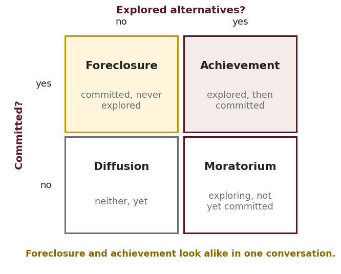

Marcia’s two questions give four identity statuses.

Diffusion: no exploration, no commitment. The person has not yet engaged with the question. This status includes the student who says the choice will be made for them by God, by destiny, or by whatever comes up.

Foreclosure: commitment without exploration. The person adopts a position whole, usually from family. It looks settled and confident from the outside, so people mistake it for maturity.

Moratorium: exploration without commitment. The person is actively in the crisis, tries different options, and changes their mind. It looks like a lack of seriousness, and it is the opposite.

Achievement: exploration followed by commitment. The person considered alternatives, chose one, and can say why. This status is rare at fourteen, although it is not impossible.

Check yourself

Jordan says he will be an engineer like his father and grandfather. He has never considered anything else and is calm and certain about it. His identity status is most likely:

He has committed Diffusion is neither exploring nor committed. Jordan is committed.

Yes Jordan adopted the commitment whole from family, with no exploration. Foreclosure looks calm and certain from the outside.

He is not exploring Moratorium is exploring without commitment.

No exploration Achievement needs alternatives considered first. He never considered any.

**Foreclosure and achievement look identical in a single conversation.** In both, the person is calm, can state the position clearly, and seems to know their own mind.

The difference is visible only over time, because exploration leaves a history of positions the person used to hold and gave up. One letter cannot show you that history, but a year can.

This is the problem in the Walkthrough, and I do not solve it there.

## Kohlberg: an introduction

We will build Kohlberg’s theory on the board on Tuesday, so this section gives only the concepts you need.

Kohlberg’s claim is about **how people justify what they do**. Two students can perform the identical act while they reason at completely different levels, so the act alone does not tell us the level.

Kohlberg describes three levels. It helps to think of them as *whose interests are in view*:

Pre-conventional: outside the group. Morality is external. People avoid punishment, act in self-interest, or trade favors.

Conventional: inside the group. Morality is the expectations of the group, such as family, friends, school or country. People follow rules because they are the rules and because rules hold the group together.

Post-conventional: above the group. Morality is principle. Rules are social agreements that people can judge and occasionally find inadequate.

Conventional reasoning is not a deficit. Most working institutions depend on it, and most adults reason this way most of the time. That includes you, most days, about most things.

True or false?

Kohlberg judged moral development by whether a person does the right thing.

Not quite Kohlberg studied **how people justify** what they do. Two students can do the identical act while they reason at different levels.

Right Kohlberg’s evidence is the reasoning, so the act alone does not answer the question.

Bring question 1 with an answer. We will examine it on Tuesday.

## Check yourself

Check yourself

Maya read the rule, considered whether she would act the same way again, concluded she would, and accepted the penalty rather than sign a statement she disagrees with. From the letter alone, the most defensible reading of her identity status is:

Defensible, and too fast Everything you can see fits achievement. The difficulty is that it also fits foreclosure, because a person can state an adopted principle just as clearly as an earned one.

Also defensible, and equally fast This reading is possible, because a fourteen-year-old can absorb “a rule that blocks understanding has the point backwards” from somewhere. Nothing in the letter shows that she did, and the confidence of the writing is not evidence for either reading.

No Moratorium is exploration *without* commitment. Maya has committed, at a cost she has named, so at least that part is certain.

Yes Marcia’s two questions are exploration and commitment. Commitment is visible here, but exploration is a history, and a single document cannot show a history. Evidence of a position she once held and abandoned would settle the question.

Noticing that a framework does not settle a question is a result, and it does not mean that you failed.

Check yourself

Two students hand in identical work late, with the same explanation. One is high in conscientiousness, one is low. The most useful thing the trait scores give you is:

Overreach Ability and personality together account for roughly 28% of the variance, so a trait score cannot forecast what one student will do on one occasion. It changes a probability slightly, and it does not tell you who will repeat the behavior.

Yes For the student high in conscientiousness, the behavior breaks the pattern, and the question is *what changed*. For the student low in conscientiousness, it fits the pattern, and the question is *what structure is missing*. The same behavior leads to two different investigations, and only the score separates them.

No, and be careful here Applying a published consequence differently because of a personality score is unequal treatment with a number attached, and it is not differentiation. Change the support and keep the policy.

Closer than A or C, and still not right The behavior is identical and its *meaning* is different. A trait measure is useful for that distinction, which is smaller and more specific than the use people usually make of it.

Carry into the Reflection

**Part 1 · Instrument.** The TIPI (Gosling et al., 2003) and the ERQ (Gross & John, 2003). Report what they said and what it means for your teaching, including whether the score changed anything you would actually do.

**Part 2 · Friction Move.** Predict → Verify: what does an AI assume when you ask it for a “typical student”? If you do the move, write your prediction **before** you prompt.

**Part 3 · Synthesis.** Describe one concrete move in your subject, based on this week’s theory.

Bring to Tuesday

Bring an answer to case question 1 that you are willing to defend. For question 2, bring one concrete piece of evidence.

Bring your own answer to Erikson or Marcia as well: which status are you in, and what is your evidence?

## Sources

Bleidorn, W., Hopwood, C. J., & Lucas, R. E. (2018). Life events and personality trait change. *Journal of Personality, 86*(1), 83–96.

Eggen, P. D., & Kauchak, D. P. (2025). *Using educational psychology in teaching* (12th ed.). Pearson. **This week: Chapter 3.**

Erikson, E. H. (1968). *Identity: Youth and crisis.* W. W. Norton.

Gosling, S. D., Rentfrow, P. J., & Swann, W. B., Jr. (2003). A very brief measure of the Big-Five personality domains. *Journal of Research in Personality, 37*(6), 504–528.

Gross, J. J., & John, O. P. (2003). Individual differences in two emotion regulation processes: Implications for affect, relationships, and well-being. *Journal of Personality and Social Psychology, 85*(2), 348–362.

Kohlberg, L. (1969). Stage and sequence: The cognitive-developmental approach to socialization. In D. A. Goslin (Ed.), *Handbook of socialization theory and research* (pp. 347–480). Rand McNally.

Mammadov, S. (2022). Big Five personality traits and academic performance: A meta-analysis. *Journal of Personality, 90*(2), 222–255.

Marcia, J. E. (1966). Development and validation of ego-identity status. *Journal of Personality and Social Psychology, 3*(5), 551–558.

McCrae, R. R., & Costa, P. T., Jr. (1997). Personality trait structure as a human universal. *American Psychologist, 52*(5), 509–516.

Poropat, A. E. (2009). A meta-analysis of the five-factor model of personality and academic performance. *Psychological Bulletin, 135*(2), 322–338.

Thomas, A., & Chess, S. (1977). *Temperament and development.* Brunner/Mazel.